# SEPA cuánto paga

A continuación se analiza el costo de los productos alimenticios en los partidos del Gran Buenos Aires y los barrios de la Ciudad Autónoma de Buenos Aires, a partir de datos del [Sistema Electrónico de Publicidad de Precios Argentinos (SEPA)](https://datos.gob.ar/dataset/produccion-precios-claros---base-sepa).

## ¿Cómo nos alimentamos?

El SEPA está integrado por una amplia diversidad de productos y sus precios, declarados por comercios minoristas de todo el país. A fines de este análisis se identificaron aquellos productos que se asimilan a las categorías que conforman la [Canasta Básica Alimentaria (CBA)](https://www.indec.gob.ar/indec/web/Nivel4-Tema-4-43-149) elaborada por el INDEC para el Gran Buenos Aires (GBA).

[figure not shown]

La CBA es una medida que representa los hábitos de consumo y las necesidades kilocalóricas y proteicas imprescindibles de una persona, tomando como referencia un varón adulto de entre 30 y 60 años, de actividad moderada, durante un mes.  
Es utilizada para la medición de la pobreza extrema en Argentina.

En este sentido, vemos que productos como la leche, el pan, la papa, la carne, las frutas y las hortalizas tienen un peso importante en la alimentación de los argentinos.

[interactive chart not shown]

## ¿Cuánto cuesta alimentarse?

Los datos del SEPA permiten conocer los precios observados de productos que integran las categorías de la CBA. En promedio, en el GBA un adulto necesitó un poco más de $245.893 para alimentarse en el mes de julio 2025.

Cabe mencionar que estos datos difieren de los publicados por INDEC para el cálculo de la inflación, en tanto se utilizan otras fuentes de datos y criterios para su medición.

Por ejemplo, por falta de representatividad en la base del SEPA, se excluyeron los siguientes productos que integran la CBA: menudencias, otras harinas (maíz), huevos y azúcar.

[interactive chart not shown]

**¿Y cuánto le cuesta a una familia alimentarse?**

Tomando como referencia la composición de los hogares realizada por INDEC, podemos ver el costo de cubrir buena parte de la CBA según precios del SEPA, para distintos hogares.

- Hogar 1: tres integrantes, compuesto por una mujer de 35 años, su hijo de 18 años y su madre de 61 años.
- Hogar 2: cuatro integrantes, compuesto por un varón de 35 años, una mujer de 31 años, un hijo de 6 años y una hija de 8 años.
- Hogar 3: cinco integrantes, constituido por un varón y una mujer, ambos de 30 años, y tres hijos de 1, 3 y 5 años.

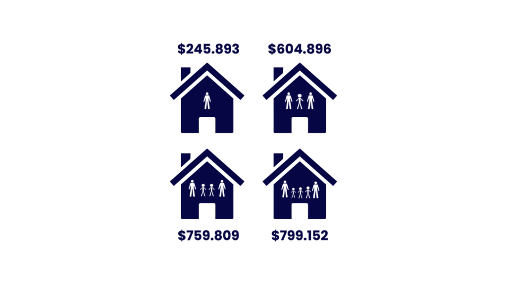

## ¿Dónde es más caro/barato alimentarse?

Los datos del SEPA permiten analizar la distribución territorial de los precios a lo largo y ancho del GBA.

*Información correspondiente a un adulto equivalente*.

San Isidro arrojó el mayor valor promedio de CBA de acuerdo a los precios relevados

Mientras que Marcos Paz registró el menor valor, con una diferencia de $51.719 pesos respecto San Isidro.

[interactive chart not shown]

## ¿Cuánto me sale cada producto?

El **café** es el producto más caro de los analizados (si bien su peso en la alimentación es bajo) por amplia diferencia, explicado por la diversidad de marcas (nacionales e importadas) y formas de presentación. En promedio, para el GBA, un kilo de café ronda los $42.842 pesos.

Por su parte, el producto más barato de la CBA es la **harina**: $1.115 pesos en promedio por kilo. Le siguen, muy de cerca, la **papa**($1.153) y la **batata** ($1.247).

[interactive chart not shown]

Al ver la relación entre aporte a la CBA y precio de los productos, vemos una relación del tipo: a mayor peso sobre la canasta, menor precio.

Los productos con mayor peso dentro de la CBA (más de 5 kilos mensuales) presentan precios promedios bajos, mientras que categorías como café y fiambres, cuyo volumen de consumo está por debajo de los 100 gramos, tienen un precio más alto.

[interactive chart not shown]

## ¿Qué productos podemos comprar?

La oferta de productos es diversa, algo que influye en los precios analizados. A mayor variedad de productos (marcas, presentaciones), mayor variabilidad en los precios.

Categorías de productos como las **bebidas alcoholicas** encabezan el ranking de cantidad de marcas que integran el SEPA. Le siguen las **galletitas** (dulces y saladas) y el **queso**.

[interactive chart not shown]

Veamos las zonas donde hay mayor cantidad de opciones de marcas, de acuerdo a los datos registrados en el SEPA.

[interactive chart not shown]

Esto se acentúa al ver la distribución según cantidad de formatos de presentación de los productos.

[interactive chart not shown]

Para más información ver pestaña de metodología